# Joint vs. Conditional vs. Marginal Distributions

Dr. Gwen Eadie

March 8, 2018

The terms *joint distribution*, *conditional distribution*, and *marginal distribution* get thrown around a lot. Let’s make sure we know what they mean before jumping into hierarchical Bayesian models.

### Joint Distribution

The *joint distribution* is the multidimensional probability distribution of all possible parameter values. For example, if you have two parameters $\theta_1$ and $\theta_2$ in your model, their joint posterior distribution would be
$$p(\theta_1, \theta_2).$$
You can plot this distribution in a two-dimensional plot with $\theta_1$ on one axis and $\theta_2$ on the other. The distribution is usually shown with contours or a scatter plot if you have samples from the distribution.

For example, let’s pretend we have a *joint distribution* that is a multivariate normal:

```r
library(MASS)
library(ggplot2)
# draw 5,000 samples from a multivariance normal distribution
samples = mvrnorm(n = 5000, mu = c(1,1), Sigma = matrix(data = c(0.3, 0.1, 0.3, 0.5), nrow = 2, ncol = 2, byrow = TRUE))
# name the columns
colnames(samples) = c("theta1", "theta2")

# make samples a data frame
samples = as.data.frame(samples)

# see what "samples" looks like using the structure function
str(samples)
```

```
## 'data.frame':    5000 obs. of  2 variables:
##  $ theta1: num  1.593 2.219 0.697 1.766 1.257 ...
##  $ theta2: num  1.882 1.777 0.499 1.115 0.982 ...
```

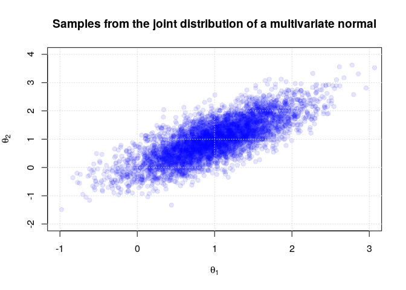

```r
# plot the samples with some transparency
# pch = point type to use
plot(x=samples$theta1, y = samples$theta2, pch=19, col=rgb(0,0,1, alpha = 0.1), ylab=expression(theta[2]), xlab=expression(theta[1]), main="Samples from the joint distribution of a multivariate normal", xlim=c(-1,3), ylim=c(-2,4))
grid()
```

### Conditional Distribution

The *conditional distribution* is the distribution of a parameter given a specific value of the other parameter(s). For example, in the above plot, we could look at the conditional distribution of $\theta_2$ given that $\theta_1=1.1$. We denote this as
$$p(\theta_2 | \theta_1=1.1).$$
If we were to write out the actual mathematical equation for the above distribution, it would be a function of $\theta_2$ alone because we set $\theta_1=1.1$. A way to visualize the conditional distribution of $\theta_2$ given $\theta_1=1.1$ is to take a slice through the joint distribution *at the value $\theta_1=1.1$* and plot the distribution/histogram of $\theta_2$ at that value. Let’s do that next!

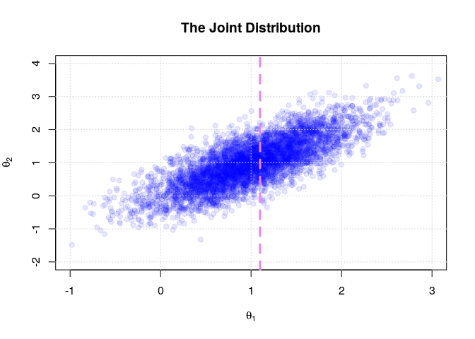

Because we have a finite sample from the joint distribution, very few (if any) of the values of $\theta_1$ equal 1.1. So let’s make a small window around $\theta_1$ = 1.1 to approximate the conditional distribution

```r
# get the indices of the rows that are TRUE in the logical statement 1.08 < theta1 < 1.12
theseones = which(samples$theta1 > 1.08 & samples$theta1 < 1.12)

# how many are in this range?
length(theseones)
```

```
## [1] 124
```

Plot the samples in a histogram with the same axis as the plot above, or as a smoothed density plot

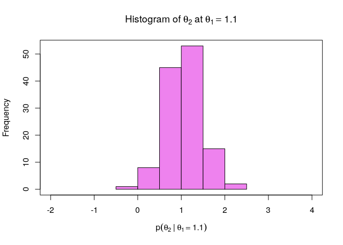

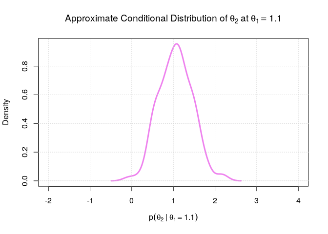

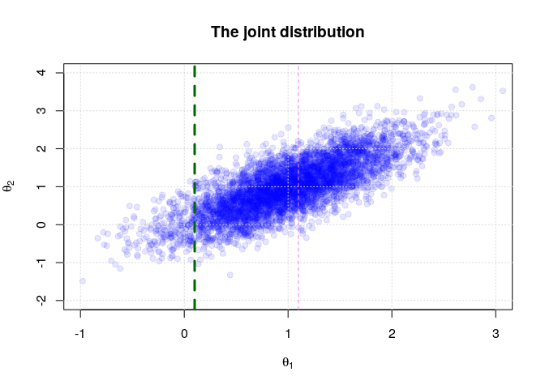

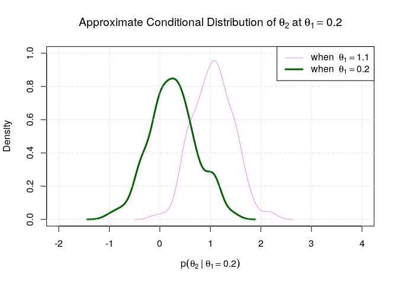

Because the conditional distribution depends on the value of $\theta_1$, we can generalize and write out the conditional distribution as a *function* of $\theta_2$ and $\theta_1$,

$$p(\theta_2|\theta_1).$$
Once we have this *function*, then we can calculate the conditional distribution of $\theta_2$ for any value of $\theta_1$.

Of course, this can all be done the other way around— we could find the conditional distribution of $\theta_1$ given $\theta_2$, $p(\theta_1|\theta_2)$.

When you know the conditional distributions for a model, then you can use a Gibbs Sampler. In the case of known conditional distributions, a Gibbs Sampler is often more efficient than a regular Metropolis algorithm. (Recall the exercise from last class!)

### Marginal Distribution

The *marginal distribution* is the distribution of a parameter regardless of the values of the other parameter(s). Mathematically, you can find the marginal distribution by integrating out the unwanted, uninteresting, or “nuisance” parameters from the joint distribution:

$$p(\theta_1) = \int{p(\theta_1, \theta_2)d\theta_2}.$$
Using our example of a multivariate normal distribution, we can look at the marginal distribution of $\theta_1$ and $\theta_2$ by making histograms of those parameters. Visually, this is like collapsing all of the points in our scatterplot onto one axis and plotting a histogram. Below we do this for both $\theta_1$ and $\theta_2$:

```r
library(psych)
```

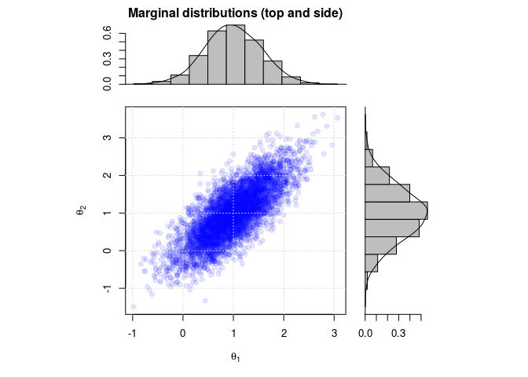

```r
# this package has a nice plotting function for a scatter plot plus side histograms

scatter.hist(x = samples$theta1, y = samples$theta2, ellipse=FALSE, correl=FALSE, density = TRUE, freq = FALSE, smooth = FALSE, pch=19, col=rgb(0,0,1,0.1), grid=TRUE, title="Marginal distributions (top and side)", xlab = expression(theta[1]), ylab=expression(theta[2]))
```

Notice that the marginal distributions are centered on the expected (i.e. the mean) values for $\theta_1$ and $\theta_2$.

When you have a Markov Chain and you plot the histogram of the samples of one of the parameters, you are looking at (an estimate of) the marginal distribution.